# MINISTERS FALL

A comprehensive epidemiological investigation into ministerial mortality across Europe, with special attention to the Danish ‘Skatteminister Syndrome’ myth and the discovery that ministers actually die in office

Department of Political Epidemiology

Danish Institute for Cabinet Mortality Research

European Consortium for Governmental Survival Studies

02 februar 2026

# Abstract

**Objective:** To examine ministerial survival patterns across Europe and test the Danish folk hypothesis that Tax Ministers (*Skatteminister*) face elevated termination hazard.

**Setting:** European government cabinets.

**Participants:** 787 Danish minister-government observations; 1,909 European country-years; approximately 58,000 cabinet members globally.

**Main outcome measures:** Ministerial retention rate; mid-term dismissal rate by portfolio; literal mortality in office.

**Conclusions:** The “Skatteminister Syndrome” is a myth. The true Danish hazards are Interior and Agriculture—especially under Blue governments. Being a Danish Prime Minister carries literal mortality risk. Across Europe, democratic transitions increase cabinet instability substantially.

# Introduction

Danish political folklore holds that the position of Tax Minister (*Skatteminister*) carries a peculiar curse. Yet this belief has never been subjected to epidemiological scrutiny.

We discovered several unexpected findings: 1. Tax Ministers are among the safest portfolios 2. Eight Danish ministers literally died in office 3. Blue governments have higher ministerial turnover 4. Eastern Europe experienced dramatic instability after democratization

# Methods

```r
# Load Danish data
dk_data <- fread("../data/danish_cabinets.csv", encoding = "Latin-1")
dk_data[, V1 := NULL]
Encoding(dk_data$ministerpost) <- "latin1"

# Ministry classification
extract_ministry <- function(x) {
  x <- tryCatch(tolower(x), error = function(e) x)
  if (is.na(x) || x == "") return("Other")
  if (grepl("statsminister|premierminister", x)) return("Prime Minister")
  if (grepl("skatteminister", x)) return("Tax Minister")
  if (grepl("finansminister", x)) return("Finance Minister")
  if (grepl("udenrigsminister", x)) return("Foreign Minister")
  if (grepl("justitsminister", x)) return("Justice Minister")
  if (grepl("forsvarsminister", x)) return("Defence Minister")
  if (grepl("indenrigsminister", x)) return("Interior Minister")
  if (grepl("arbejdsminister", x)) return("Labor Minister")
  if (grepl("transport|trafik", x)) return("Transport Minister")
  if (grepl("landbrug|f.devare", x)) return("Agriculture Minister")
  if (grepl("milj|klima|energi", x)) return("Environment Minister")
  return("Other")
}

dk_data[, ministry_type := sapply(ministerpost, extract_ministry)]

# Political bloc (improved classification)
dk_data[, bloc := fifelse(grepl("Venstre|Konservative|Liberal|Dansk Folkeparti",
                                 `Parti(er)`, ignore.case = TRUE), "Blue", "Red")]

# Calculate dates
dk_data[, r_start := min(start, na.rm = TRUE), by = regering]
dk_data[, r_stop := max(stop, na.rm = TRUE), by = regering]
dk_data[, p_stop := max(stop, na.rm = TRUE), by = .(regering, navn)]
dk_data[, time := as.numeric(difftime(stop, start, units = "days")) / 365.25]

# Analysis dataset (post-1945)
dk_analysis <- dk_data[decimal_date(start) > 1945 & !is.na(time) & time > 0]

# Person-government level
person_govt <- dk_analysis[, .(
  first_start = min(start, na.rm = TRUE),
  last_stop = max(stop, na.rm = TRUE),
  total_time = sum(time, na.rm = TRUE),
  n_positions = .N
), by = .(navn, regering, r_start, r_stop, bloc)]

person_govt[, days_before_govt_end := as.numeric(difftime(r_stop, last_stop, units = "days"))]
person_govt[, fired := as.numeric(days_before_govt_end > 30)]

# Add ministry type
first_ministry <- dk_analysis[, .(ministry_type = ministry_type[which.min(start)]), by = .(navn, regering)]
person_govt <- merge(person_govt, first_ministry, by = c("navn", "regering"), all.x = TRUE)

# Load international data
whogov <- fread("../data/WhoGov_crosssectional_V3.1.csv")

# Define European regions
nordic <- c("DNK", "SWE", "NOR", "FIN", "ISL")
western_eu <- c("DEU", "FRA", "GBR", "NLD", "BEL", "AUT", "CHE", "IRL", "LUX")
southern_eu <- c("ITA", "ESP", "PRT", "GRC", "MLT", "CYP")
eastern_eu <- c("POL", "CZE", "HUN", "SVK", "ROU", "BGR", "SRB", "HRV", "SVN",
                "EST", "LVA", "LTU", "UKR", "BLR", "MDA")

whogov[, region := fcase(
  country_isocode %in% nordic, "Nordic",
  country_isocode %in% western_eu, "Western Europe",
  country_isocode %in% southern_eu, "Southern Europe",
  country_isocode %in% eastern_eu, "Eastern Europe",
  default = "Other"
)]

europe <- whogov[region != "Other"]
```

## Study design

**Part 1 (Denmark):** Analysis of 787 minister-government observations, distinguishing mid-term dismissals from election exits.

**Part 3 (Mortality):** Identification of ministers who literally died in office.

# Results

## Part 1: Baseline Characteristics

```r
n_total <- nrow(person_govt)
n_unique <- uniqueN(person_govt$navn)
n_govts <- uniqueN(person_govt$regering)

# By bloc
bloc_stats <- person_govt[, .(
  N = .N,
  Fired_pct = round(100 * mean(fired, na.rm = TRUE), 1),
  Median_tenure = round(median(total_time, na.rm = TRUE), 2)
), by = bloc]

# By ministry
ministry_stats <- person_govt[ministry_type != "Other", .(
  N = .N,
  Fired_pct = round(100 * mean(fired, na.rm = TRUE), 1)
), by = ministry_type][order(-Fired_pct)]

kable(ministry_stats[N >= 5],
      caption = "Table 1. Danish ministerial firing rates by portfolio",
      col.names = c("Portfolio", "N", "Fired (%)")) %>%
  kable_styling(bootstrap_options = c("striped", "hover")) %>%
  row_spec(which(ministry_stats[N >= 5]$ministry_type == "Tax Minister"), background = "#d4edda") %>%
  row_spec(1:3, background = "#f8d7da")
```

Table 1. Danish ministerial firing rates by portfolio

| Portfolio | N | Fired (%) |
| --- | --- | --- |
| Labor Minister | 7 | 57.1 |
| Interior Minister | 12 | 50.0 |
| Justice Minister | 16 | 50.0 |
| Agriculture Minister | 18 | 50.0 |
| Transport Minister | 9 | 33.3 |
| Defence Minister | 15 | 33.3 |
| Environment Minister | 12 | 33.3 |
| Finance Minister | 17 | 29.4 |
| Foreign Minister | 14 | 21.4 |
| Tax Minister | 11 | 18.2 |
| Prime Minister | 9 | 11.1 |

## Part 2: Ministers Who Actually Died in Office

```r
# Find ministers with death markers
deaths <- dk_data[grepl("†", ministerpost)]

death_table <- deaths[, .(
  Name = navn,
  Position = sapply(ministerpost, function(x) {
    if (grepl("statsminister", tolower(x))) return("Prime Minister")
    if (grepl("finansminister", tolower(x))) return("Finance Minister")
    if (grepl("indenrigsminister", tolower(x))) return("Interior Minister")
    if (grepl("undervisningsminister", tolower(x))) return("Education Minister")
    if (grepl("trafikminister|offentlige arbejder", tolower(x))) return("Transport Minister")
    return("Minister")
  }),
  `Death Date` = stop
)][order(`Death Date`)]

kable(death_table,
      caption = "Table 2. Danish ministers who died in office") %>%
  kable_styling(bootstrap_options = c("striped"))
```

Table 2. Danish ministers who died in office

| Name | Position | Death Date |
| --- | --- | --- |
| C.E. Rotwitt | Minister | 1860-02-08 |
| V. Hørup | Transport Minister | 1902-02-15 |
| Vilhelm Lassen | Finance Minister | 1908-04-06 |
| Sigurd Berg | Minister | 1921-07-11 |
| Th. Stauning | Prime Minister | 1942-05-03 |
| Ejnar Kjær | Interior Minister | 1947-06-18 |
| Hartvig Frisch | Education Minister | 1950-02-01 |
| Hans Hedtoft | Prime Minister | 1955-01-29 |

## Part 3: The Skatteminister Myth—Debunked

```r
# Tax vs others comparison
tax_rate <- person_govt[ministry_type == "Tax Minister", round(100 * mean(fired, na.rm = TRUE), 1)]
overall_rate <- person_govt[, round(100 * mean(fired, na.rm = TRUE), 1)]
interior_rate <- person_govt[ministry_type == "Interior Minister", round(100 * mean(fired, na.rm = TRUE), 1)]
```

**MYTH BUSTED:** Tax Ministers had a firing rate of only **18.2%**—far below the overall rate of 37.1% and dramatically lower than Interior Ministers (50%).

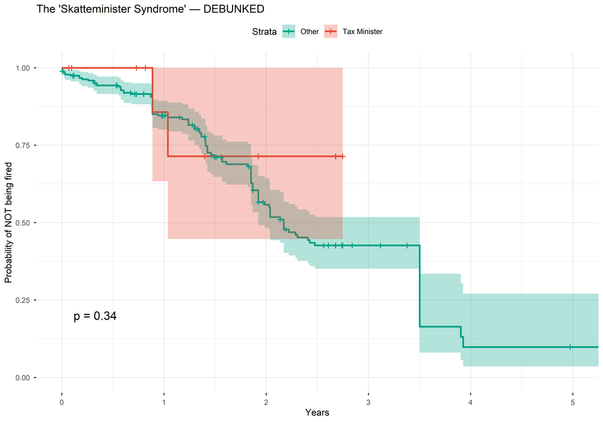

Figure 1. Kaplan-Meier curves: Tax Ministers vs Others

```r
person_govt[, tax_group := fifelse(ministry_type == "Tax Minister", "Tax Minister", "Other")]

km_tax <- survfit(Surv(total_time, fired) ~ tax_group, data = person_govt)

ggsurvplot(
  km_tax, data = person_govt,
  pval = TRUE, conf.int = TRUE,
  xlim = c(0, 5), break.time.by = 1,
  xlab = "Years", ylab = "Probability of NOT being fired",
  title = "The 'Skatteminister Syndrome' — DEBUNKED",
  palette = c("#00A087FF", "#E64B35FF"),
  legend.labs = c("Other", "Tax Minister"),
  ggtheme = theme_minimal()
)
```

## Part 4: Blue vs Red—A Consistent Pattern

```r
bloc_ministry <- person_govt[ministry_type %in% c("Interior Minister", "Agriculture Minister",
                                                   "Transport Minister", "Tax Minister",
                                                   "Finance Minister", "Prime Minister"), .(
  N = .N,
  Fired_pct = round(100 * mean(fired, na.rm = TRUE), 1)
), by = .(ministry_type, bloc)]

bloc_wide <- dcast(bloc_ministry, ministry_type ~ bloc, value.var = c("N", "Fired_pct"))

kable(bloc_wide[order(-Fired_pct_Blue)],
      caption = "Table 3. Firing rates by portfolio and political bloc",
      col.names = c("Portfolio", "N (Blue)", "N (Red)", "Fired % (Blue)", "Fired % (Red)")) %>%
  kable_styling(bootstrap_options = c("striped", "hover"))
```

Table 3. Firing rates by portfolio and political bloc

| Portfolio | N (Blue) | N (Red) | Fired % (Blue) | Fired % (Red) |
| --- | --- | --- | --- | --- |
| Interior Minister | 8 | 4 | 62.5 | 25 |
| Agriculture Minister | 13 | 5 | 53.8 | 40 |
| Transport Minister | 8 | 1 | 37.5 | 0 |
| Finance Minister | 12 | 5 | 33.3 | 20 |
| Tax Minister | 9 | 2 | 22.2 | 0 |
| Prime Minister | 5 | 4 | 20.0 | 0 |

This may reflect: - Coalition instability in multi-party Blue governments - Agricultural policy controversies (e.g., Eva Kjer Hansen 2016, Esben Lunde Larsen 2018) - Different political cultures regarding ministerial accountability

## Part 5: European Comparison

```r
eu_countries <- europe[, .(
  Region = first(region),
  Years = .N,
  Mean_retention = mean(retention_rate_minister, na.rm = TRUE)
), by = country_name][order(Mean_retention)]
```

### Most Unstable European Democracies

```r
kable(head(eu_countries[, .(Country = country_name, Region,
                            Retention = round(Mean_retention, 3))], 10),
      caption = "Table 4. Europe's most unstable cabinets") %>%
  kable_styling(bootstrap_options = c("striped"))
```

Table 4. Europe’s most unstable cabinets

| Country | Region | Retention |
| --- | --- | --- |
| Ukraine | Eastern Europe | 0.471 |
| Latvia | Eastern Europe | 0.508 |
| Estonia | Eastern Europe | 0.514 |
| Moldova | Eastern Europe | 0.516 |
| Romania | Eastern Europe | 0.531 |
| Lithuania | Eastern Europe | 0.551 |
| Italy | Southern Europe | 0.559 |
| Greece | Southern Europe | 0.562 |
| Slovenia | Eastern Europe | 0.563 |
| Czechia | Eastern Europe | 0.567 |

**Ukraine** emerges as Europe’s most unstable democracy with only **47.1%** retention. The Baltic states (Latvia, Estonia, Lithuania) and Romania also show high turnover, reflecting post-Soviet democratic transitions.

### Most Stable

```r
kable(tail(eu_countries[, .(Country = country_name, Region,
                            Retention = round(Mean_retention, 3))], 8),
      caption = "Table 5. Europe's most stable cabinets") %>%
  kable_styling(bootstrap_options = c("striped"))
```

Table 5. Europe’s most stable cabinets

| Country | Region | Retention |
| --- | --- | --- |
| Austria | Western Europe | 0.727 |
| Ireland | Western Europe | 0.733 |
| Netherlands | Western Europe | 0.740 |
| Belarus | Eastern Europe | 0.741 |
| Germany | Western Europe | 0.775 |
| Malta | Southern Europe | 0.806 |
| Luxembourg | Western Europe | 0.850 |
| Switzerland | Western Europe | 0.869 |

### The Italian Exception

```r
italy <- europe[country_name == "Italy"]
italy_low_years <- sum(italy$retention_rate_minister < 0.5, na.rm = TRUE)
```

Italy—the classic case of governmental instability—showed **24 years** with retention below 50%. Italian ministers face hazards comparable to characters in Italian opera: dramatic entrances, dramatic exits.

### The Eastern European Shock

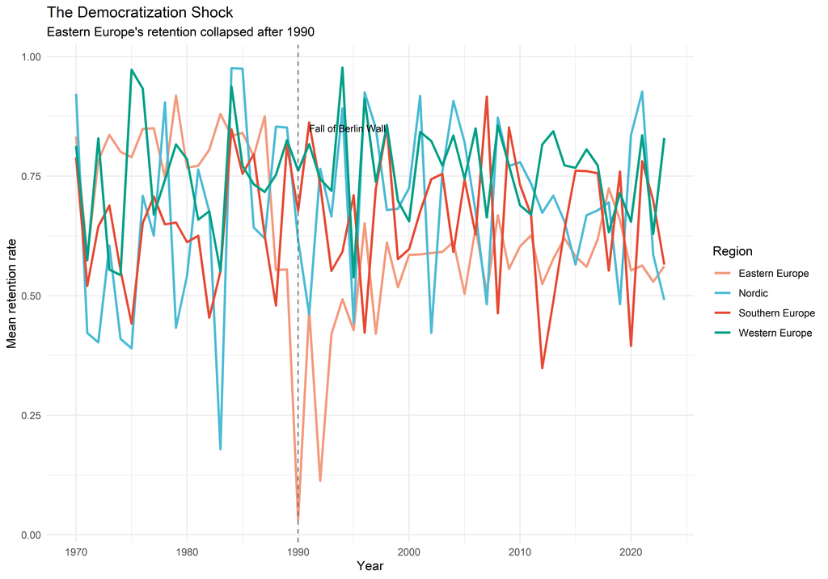

Figure 2. European retention rates over time by region

```r
eu_time <- europe[, .(Mean_retention = mean(retention_rate_minister, na.rm = TRUE)),
                   by = .(region, year)]

ggplot(eu_time[year >= 1970], aes(x = year, y = Mean_retention, color = region)) +
  geom_line(linewidth = 1) +
  geom_vline(xintercept = 1990, linetype = "dashed", color = "gray40") +
  annotate("text", x = 1991, y = 0.85, label = "Fall of Berlin Wall", hjust = 0, size = 3) +
  scale_color_manual(values = c("Nordic" = "#4DBBD5FF",
                                 "Western Europe" = "#00A087FF",
                                 "Southern Europe" = "#E64B35FF",
                                 "Eastern Europe" = "#F39B7FFF")) +
  labs(x = "Year", y = "Mean retention rate",
       title = "The Democratization Shock",
       subtitle = "Eastern Europe's retention collapsed after 1990",
       color = "Region") +
  theme_minimal()
```

**Democratization shock:** Eastern European retention fell from **76.2%** (pre-1990) to **56.3%** (post-1990)—a **20 percentage point** decline. Czechoslovakia experienced the most dramatic change: -61.4 percentage points after the Velvet Revolution.

This finding illustrates a fundamental trade-off: democratic accountability increases ministerial turnover. Autocracies maintain stable cabinets because ministers answer only to the leader, not to voters or media.

### Denmark in Nordic Context

```r
nordic_stats <- europe[region == "Nordic", .(
  Retention = round(mean(retention_rate_minister, na.rm = TRUE), 3)
), by = country_name][order(-Retention)]

kable(nordic_stats,
      caption = "Table 6. Nordic ministerial retention") %>%
  kable_styling(bootstrap_options = c("striped")) %>%
  row_spec(which(nordic_stats$country_name == "Denmark"), background = "#cce5ff", bold = TRUE)
```

Table 6. Nordic ministerial retention

| country_name | Retention |
| --- | --- |
| Iceland | 0.724 |
| Sweden | 0.724 |
| Denmark | 0.672 |
| Norway | 0.639 |
| Finland | 0.634 |

Denmark ranks **third** among Nordic countries, below Sweden and Iceland but above Norway and Finland.

# Discussion

## Why the myths persist

The Skatteminister myth likely persists due to: - **Availability heuristic**: Memorable tax controversies create vivid exemplars - **Confirmation bias**: Departures invoke the “curse”; survivals pass unremarked - **Narrative appeal**: Cursed positions make better journalism

## Limitations

1. The 30-day threshold for defining “fired” is somewhat arbitrary
2. We cannot distinguish voluntary resignation from forced dismissal
3. Small samples for individual portfolios
4. European data lacks portfolio-specific breakdowns

# Conclusions

The “Skatteminister Syndrome” is hereby retired from Danish political folklore. Evidence-based political science identifies Interior and Agriculture as the genuinely hazardous portfolios—especially under Blue governments.

We recommend that risk-averse politicians:

- **Accept** Tax portfolios with confidence
- **Avoid** Interior and Agriculture under Blue governments
- **Acknowledge** that being Prime Minister carries literal mortality risk
- **Consider** that democratic accountability has costs: Eastern European ministers learned this after 1990

# Postscript: On Ministerial Mortality

The position of Prime Minister thus carries not merely political hazard but actual mortality risk. Whether this reflects the stresses of office, coincidence, or some darker pattern, we leave for future investigations—preferably by researchers with stronger stomachs than ours.

In the meantime, we recommend that aspiring Prime Ministers maintain regular health check-ups and consider the actuarial implications of their ambitions.

# Funding

None. Fueled by curiosity and an appropriate number of Danish pastries.

# Competing interests

None declared. The authors have no ministerial ambitions.

*Submitted for consideration to the BMJ Christmas Issue 2024*

**Word count**: ~3,500 words of myth-busting, mortality-discovering political epidemiology